# Recent College Graduates: Quick Facts

### Sample size and composition over time

These diagnostics show monthly row counts, the weighted 16+ population against FRED `CNP16OV`, and the components of the RCG definition: age 21–26, bachelor’s degree or higher, and their intersection.

```r
monthly_diag <- cps[, .(
  n_rows                = .N,
  weighted_total_16plus = sum(WTFINL * (AGE >= 16), na.rm = TRUE),
  share_2126            = sum(WTFINL * (AGE >= 21 & AGE <= 26), na.rm = TRUE) /
                          sum(WTFINL, na.rm = TRUE),
  share_bachelor        = sum(WTFINL * (EDUC >= 111),           na.rm = TRUE) /
                          sum(WTFINL, na.rm = TRUE),
  share_rcg             = sum(WTFINL * is_rcg,                  na.rm = TRUE) /
                          sum(WTFINL, na.rm = TRUE)
), by = date]
setorder(monthly_diag, date)
monthly_diag[, `:=`(
  weighted_total_16plus_m = weighted_total_16plus / 1e6,
  n_rows_ma               = roll_mean12(n_rows),
  share_2126_pct          = 100 * share_2126,
  share_bachelor_pct      = 100 * share_bachelor,
  share_rcg_pct           = 100 * share_rcg
)]

# FRED civilian noninstitutional population, 16+ (thousands, monthly).
# BLS uses civilian noninstitutional population controls in CPS weighting.
cnp <- as.data.table(fredr(
  series_id = "CNP16OV",
  observation_start = as.Date("1994-01-01")
))[, .(date, cnp16ov_m = value / 1000)]

monthly_diag <- merge(monthly_diag, cnp, by = "date", all.x = TRUE)
monthly_diag[, weighted_total_16plus_m_ma := roll_mean12(weighted_total_16plus_m)]
```

**Unweighted rows per month**

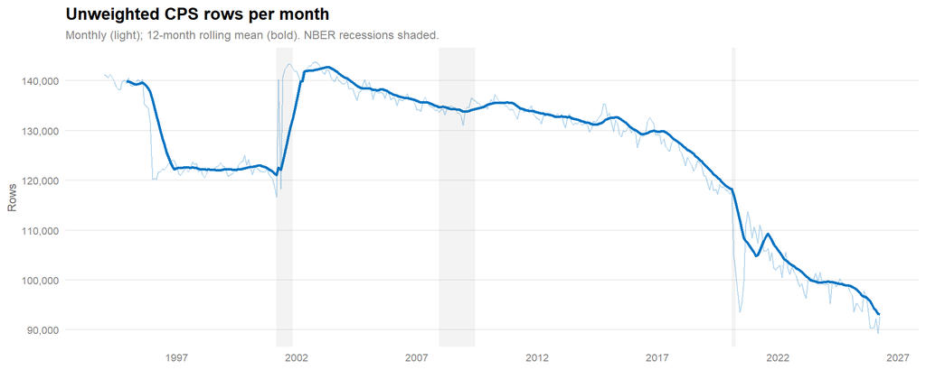

```r
p_rows <- ggplot(monthly_diag, aes(x = date)) +
  geom_line(aes(y = n_rows),    color = jco[1], alpha = 0.3, linewidth = 0.4) +
  geom_line(aes(y = n_rows_ma), color = jco[1], linewidth = 1.0) +
  scale_y_continuous(labels = label_comma()) +
  scale_x_date(date_breaks = "5 years", date_labels = "%Y") +
  labs(title = "Unweighted CPS rows per month",
       subtitle = "Monthly (light); 12-month rolling mean (bold). NBER recessions shaded.",
       x = NULL, y = "Rows")
add_recessions(p_rows)
```

**CPS 16+ population vs FRED CNP16OV**

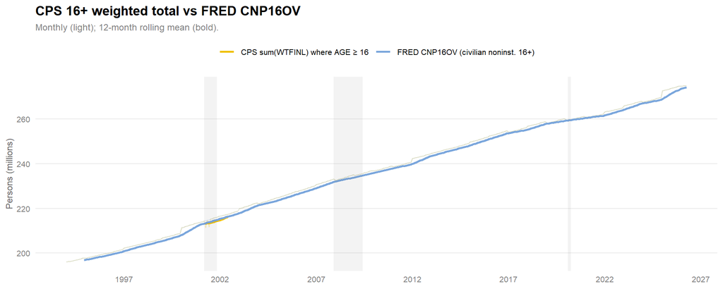

```r
wgt_long <- melt(
  monthly_diag,
  id.vars = "date",
  measure.vars = c("weighted_total_16plus_m", "cnp16ov_m"),
  variable.name = "series", value.name = "millions"
)
wgt_long[, series := factor(
  series,
  levels = c("weighted_total_16plus_m", "cnp16ov_m"),
  labels = c("CPS sum(WTFINL) where AGE ≥ 16",
             "FRED CNP16OV (civilian noninst. 16+)")
)]
wgt_long[, ma := roll_mean12(millions), by = series]

wgt_cols <- c(
  "CPS sum(WTFINL) where AGE ≥ 16"        = jco[2],
  "FRED CNP16OV (civilian noninst. 16+)"  = jco[5]
)

p_wgt <- ggplot(wgt_long, aes(x = date, color = series)) +
  geom_line(aes(y = millions), alpha = 0.25, linewidth = 0.4) +
  geom_line(aes(y = ma),       linewidth = 1.0) +
  scale_color_manual(values = wgt_cols) +
  scale_y_continuous(labels = label_comma()) +
  scale_x_date(date_breaks = "5 years", date_labels = "%Y") +
  labs(title = "CPS 16+ weighted total vs FRED CNP16OV",
       subtitle = "Monthly (light); 12-month rolling mean (bold).",
       x = NULL, y = "Persons (millions)")
add_recessions(p_wgt)
```

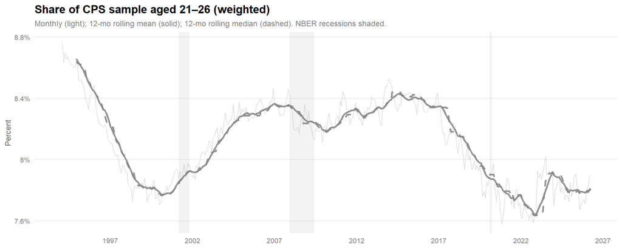

```r
rate_panel(monthly_diag, "share_2126_pct",
           "Share of CPS sample aged 21–26 (weighted)", jco[3])
```

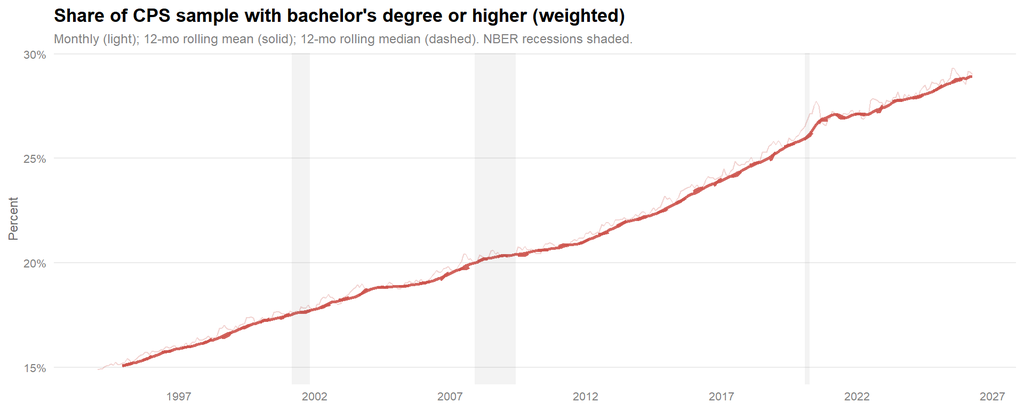

```r
rate_panel(monthly_diag, "share_bachelor_pct",
           "Share of CPS sample with bachelor's degree or higher (weighted)", jco[4])
```

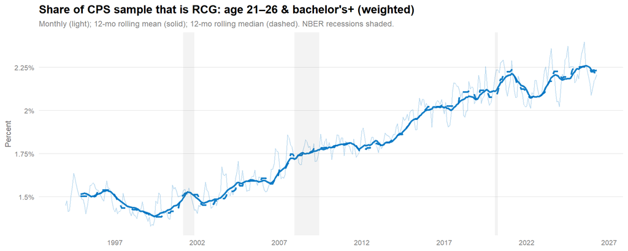

```r
rate_panel(monthly_diag, "share_rcg_pct",
           "Share of CPS sample that is RCG: age 21–26 & bachelor's+ (weighted)", jco[1])
```

### Recoded indicators

Counts below are person-months from January 1994 through April 2026, not unique people. CPS has a rotating panel, so the same person can appear in more than one monthly file. The RCG unemployed row gives the sample size behind the RCG-specific unemployment estimates.

```r
recode_summary <- data.table(
  Indicator = c(
    "RCG (age 21–26 & bachelor's+)",
    "YLB (age 18–25 & less than bachelor's)",
    "In labor force (LABFORCE == 2)",
    "Employed (EMPSTAT in {10, 12})",
    "Unemployed (EMPSTAT in {20, 21, 22})",
    "RCG ∩ in labor force",
    "RCG ∩ unemployed",
    "YLB ∩ unemployed",
    "Unemployed ∩ New Entrant (WHYUNEMP == 6)",
    "Unemployed ∩ Reentrant (WHYUNEMP == 5)"
  ),
  `Unweighted rows` = c(
    format(sum(cps$is_rcg,                    na.rm = TRUE), big.mark = ","),
    format(sum(cps$is_ylb,                    na.rm = TRUE), big.mark = ","),
    format(sum(cps$is_lf,                     na.rm = TRUE), big.mark = ","),
    format(sum(cps$is_emp,                    na.rm = TRUE), big.mark = ","),
    format(sum(cps$is_unemp,                  na.rm = TRUE), big.mark = ","),
    format(sum(cps$is_rcg & cps$is_lf,        na.rm = TRUE), big.mark = ","),
    format(sum(cps$is_rcg & cps$is_unemp,     na.rm = TRUE), big.mark = ","),
    format(sum(cps$is_ylb & cps$is_unemp,     na.rm = TRUE), big.mark = ","),
    format(sum(cps$is_ne,                     na.rm = TRUE), big.mark = ","),
    format(sum(cps$is_re,                     na.rm = TRUE), big.mark = ",")
  )
)

recode_summary |> gt() |> style_gt()
```

| Indicator | Unweighted rows |
| --- | --- |
| RCG (age 21–26 & bachelor's+) | 778,788 |
| YLB (age 18–25 & less than bachelor's) | 4,109,648 |
| In labor force (LABFORCE == 2) | 24,530,281 |
| Employed (EMPSTAT in {10, 12}) | 23,220,406 |
| Unemployed (EMPSTAT in {20, 21, 22}) | 1,309,875 |
| RCG ∩ in labor force | 662,040 |
| RCG ∩ unemployed | 30,850 |
| YLB ∩ unemployed | 304,587 |
| Unemployed ∩ New Entrant (WHYUNEMP == 6) | 114,845 |
| Unemployed ∩ Reentrant (WHYUNEMP == 5) | 378,503 |